# Comunicar con RStudio

## Tarjetas - contenido

La sintaxis de una tarjeta incluída en el diseño de página de un tablero tiene la forma:

```yaml
::: {.card title="Título de la tarjeta"}

Aquí va el texto o elemento markdown / HTML a publicar

:::
```

El contenido de las tarjetas puede ser cualquiera de los elementos vistos anteriormente en Quarto basados en markdown o código HTML puro. También es útil incorporar valores dinámicos mediante código en línea.

## Cajas de valor

Los cajas de valor son una excelente forma de mostrar valores simples de manera destacada dentro de un tablero.

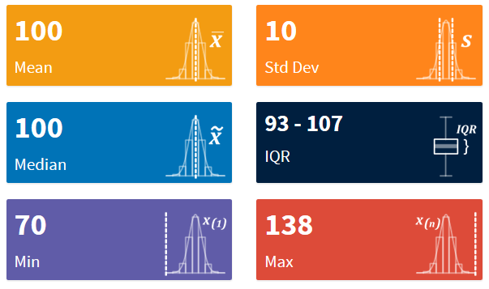

## Cajas de valor

La sintaxis dentro de un fragmento de código R tiene la siguiente estructura:

````yaml
```{r}
#| content: valuebox
#| title: "Texto de la caja de valor"

list(
  icon = "nombre-icono",
  color = "color de la caja",
  value = valor a mostrar)
)

```
````

Los íconos pueden ser cualquiera de los 2000 disponibles en [íconos de bootstrap](https://icons.getbootstrap.com/)

En color puede especificarse alguno de la paleta general hexadecimal o con palabras reservadas tipo `primary`, `success`, `danger`, etc. Estos colores variaran según el tema estético aplicado al tablero.

## Cajas de valor

También se pueden crear cajas de valores usando Markdown simple, en cuyo caso normalmente se incluye el valor mediante una expresión en línea. Por ejemplo:

```yaml
## Row

::: {.valuebox icon="heart-pulse-fill" color="danger"}
Cantidad de enfermos

´{r} enfermos´
:::
```

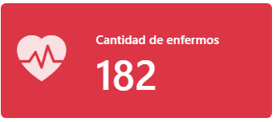

## Tablas desde código

Se pueden incluir tablas dentro de estos tableros de dos formas:

- Como una presentación tabular simple
- Como un widget interactivo que incluya, por ejemplo ordenamiento y filtrado.

Si lo que se quiere mostrar es una cantidad pequeña de observaciones se puede utilizar funciones de `knitr` o `flextable` sin problemas.

````yaml
```{r}
knitr::kable(datos)

# o con flextable

datos |>
  flextable()
```
````

Estas tablas tendrán composición Markdown simples y llenan automáticamente al contenedor (desplazándose horizontal y verticalmente según sea necesario).

## Tablas desde código

Si la tabla que queremos mostrar tiene muchos registros o es conveniente que se pueda ordenar de formas ascendente o descendente por alguna/s variable/s o hacer alguna busqueda particular, tenemos que hacer uso de algún paquete que incluya cierta interactividad.

Por ejemplo, el paquete DT, esta basado en una interfaz de JavaScript DataTables y agrega filtrado, paginación y ordenamiento a sus salidas.

````yaml
```{r}
library(DT)
datatable(datos)
```
````

## Tablas desde código

| pais | continente | anio | esperanza_de_vida |
| --- | --- | --- | --- |
| Afganistán | Asia | 1952 | 28.801 |
| Afganistán | Asia | 1957 | 30.332 |
| Afganistán | Asia | 1962 | 31.997 |
| Afganistán | Asia | 1967 | 34.02 |
| Afganistán | Asia | 1972 | 36.088 |
| Afganistán | Asia | 1977 | 38.438 |
| Afganistán | Asia | 1982 | 39.854 |
| Afganistán | Asia | 1987 | 40.822 |
| Afganistán | Asia | 1992 | 41.674 |
| Afganistán | Asia | 1997 | 41.763 |

[output cut: 1694 more lines]

## Gráficos desde código

Los gráficos son los elementos más comunes mostrados en tableros. Al igual que las tablas pueden ser estáticos o dinámicos/interactivos.

- Los estáticos serán gráficos generalmente producidos con **ggplot2**
- Los dinámicos estarán basados en alguna librería de JavaScript que incluyen los paquetes especiales `ggiraph`, `Plotly`, `highcharter`, `dygraphs`, etc.
- También hay algunas librerías para mostrar mapas como `Leaflet` o `mapview`

## Gráficos desde código

Ejemplo con `ggiraph`

[interactive chart not shown]

## htmlwidgets

Estos componentes dinámicos / interactivos basados en JavaScript mostrados en los paquetes para tablas y gráficos anteriores pertenecen a htmlwidgets.

En el sitio https://www.htmlwidgets.org/ perteneciente a RStudio / Posit se encuentran publicada la galería de librerías disponibles.

Cada uno de los 132 paquetes citados tienen su propia página con la referencia de sus funciones, modo de uso, ejemplos, etc.

Estos componentes se pueden incluir en dashboards con y sin servidor Shiny asociado y también en documentos HTML de Quarto.